# Maple Syrup Sugar Level Prediction

### Problem

Sap is collected from trees for the production of Maple Syrup. The higher the concentration of sugar in the sap, the more time and money is saved by a producer. This study has the objective to develop a model to predict the sugar level in the sap given a few predictor variables. Given a model, the producer would be able to select trees with maximum predicted sugar levels for collection.

Data:

- TreeID: tree identification number.
- Days: number of days that elapsed from the first tapping of the tree to collection.
- DBH: diameter at breast height of the tree, in inches.
- Growth: measure of the yearly growth rate of the tree.
- Sun: sun exposure index. *Note: expensive to be measured.*
- Temp: overnight minimum temperature the evening before collection, in Fahrenheit.
- **Sugar**: percentage of sugar in the sap at the time of collection.

### First look at the data

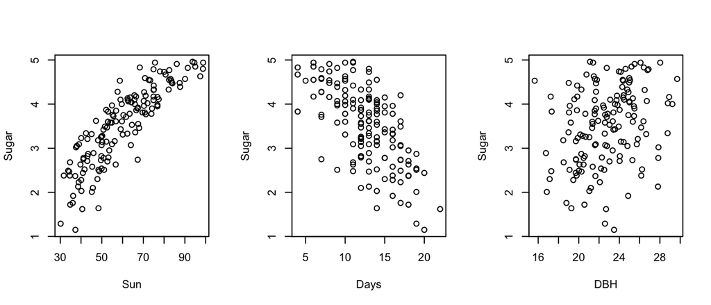

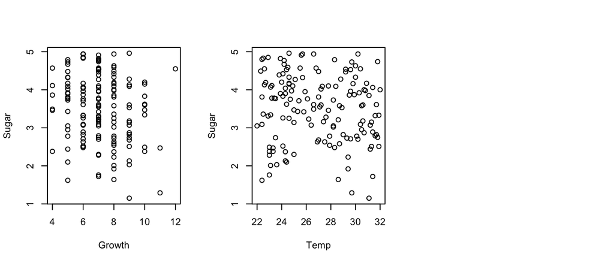

```r
# load data
maple <- read.table("Maple Data.txt", header = TRUE)
```

Looking at the plots above, the variables Sun and Days appear to have a clear relation with the sugar level. It is less evident, but the BDH plot seem to have a considerable concentration of points in the diagonal, indicating a possible relation. No relation can be clearly seen in the last two plots.

```r
# fit multiple linear regression over all variables
mod <- lm(maple$Sugar ~ maple$Sun+maple$Days+maple$DBH+maple$Growth+maple$Temp)
vif(mod) # VIF
```

```
##    maple$Sun   maple$Days    maple$DBH maple$Growth   maple$Temp
##     1.529136     1.432477     1.049772     1.057829     1.026269
```

The variation inflation factors above are all close to 1, indicating that there is low correlation between the predictor variables.

It was decided to model the system as a Multiple Linear Regression. It assumes that the model is correct and that the error terms are independent, have equal variance, and follow a normal distribution.

### Multiple linear regression

At first, this model was fitted:
$$\text{Sugar} = \beta_0+\beta_{Days}\text{Days}+\beta_{DBH}\text{DBH}+\beta_{Growth}\text{Growth}+\beta_{Sun}\text{Sun}+\beta_{Temp}\text{Temp}$$
The model resulted in a large estimated intercept. The variables Days, DBH, and Sun dominated the model with higher estimated coefficients, as expected by looking at the scatter plots above. The t-tests of the coefficients ($H_0:\beta_{X}=0$ given all other $\beta$s) resulted in very high p-values for the variables Growth and Temp, which might indicate that they do not add much important information to the prediction of sugar level. It was obtained an adjusted $R^2$ of 0.8016.

But, while checking the model assumptions, the residuals vs fitted plot below was obtained. It doesn’t look too bad, but there is clearly some curvature and the variance doesn’t seem homogeneous (smaller in the right side). Therefore, a few transformations on the data were tried. The best result found was the power transformation of the sugar level by a factor of 2 (Sugar$^2$). The power 2 was chosen using the Box-cox transformation, as seen below. The log-likelihood is maximized at $\lambda = 2.06 \approx 2$.

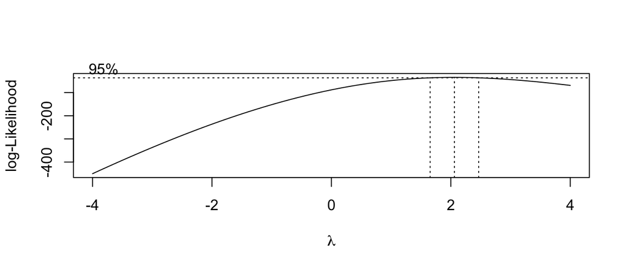

```r
# fit transformed model
b <- boxcox((maple$Sugar) ~ maple$Sun+maple$Days+maple$DBH+maple$Growth+maple$Temp,
            lambda = seq(-4, 4, by = 0.5))
```

```r
bc <- cbind(b$x, b$y) # combine lambda and lik
# values sorted to identify the lambda value for the maximum log likelihood
head(bc[order(-b$y),], n = 5)
```

```
##          [,1]      [,2]
## [1,] 2.060606 -34.35832
## [2,] 1.979798 -34.41779
## [3,] 2.141414 -34.45141
## [4,] 1.898990 -34.63337
## [5,] 2.222222 -34.69303
```

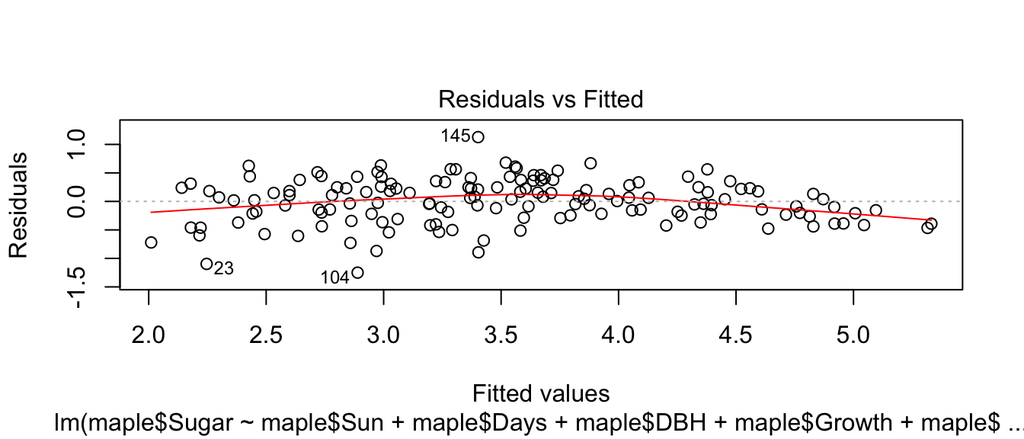

### Transformed model (Sugar$^2$)

The transformed model is:
$$\text{Sugar}^2 = \beta_0+\beta_{Days}\text{Days}+\beta_{DBH}\text{DBH}+\beta_{Growth}\text{Growth}+\beta_{Sun}\text{Sun}+\beta_{Temp}\text{Temp}$$

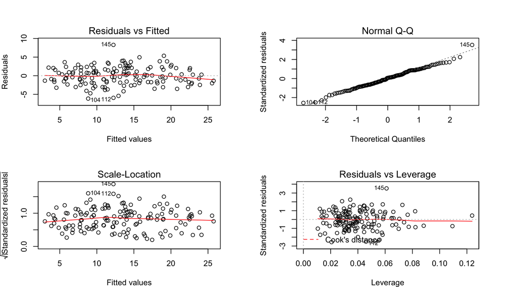

```r
# fit transformed model
mod2 <- lm((maple$Sugar)^2 ~ maple$Sun+maple$Days+maple$DBH+maple$Growth+maple$Temp)
par(mfrow=c(2,2), mar=c(4,4,4,4));plot(mod2) # residual plots
```

As seen above, the assumptions for the linear regression look better. The QQ plot shows a good normal distribution of residuals. The Residuals vs Fitted plot shows good linearity, less curvature than the previous model, and acceptable constant variance.

```r
summary(mod2) # display summary of regression
```

```
##
## Call:
## lm(formula = (maple$Sugar)^2 ~ maple$Sun + maple$Days + maple$DBH +
##     maple$Growth + maple$Temp)
##
## Residuals:
##     Min      1Q  Median      3Q     Max
## -6.1429 -1.6546  0.1442  1.8563  8.2828
##
## Coefficients:
##               Estimate Std. Error t value Pr(>|t|)
## (Intercept)  -3.273364   3.123610  -1.048  0.29645
## maple$Sun     0.266444   0.014894  17.890  < 2e-16 ***
## maple$Days   -0.385144   0.064911  -5.933 2.16e-08 ***
## maple$DBH     0.221151   0.071092   3.111  0.00226 **
## maple$Growth  0.070900   0.124253   0.571  0.56917
## maple$Temp   -0.007929   0.066282  -0.120  0.90495
## ---
## Signif. codes:  0 '***' 0.001 '**' 0.01 '*' 0.05 '.' 0.1 ' ' 1
##
## Residual standard error: 2.427 on 142 degrees of freedom
## Multiple R-squared:  0.8411, Adjusted R-squared:  0.8355
## F-statistic: 150.3 on 5 and 142 DF,  p-value: < 2.2e-16
```

The estimated coefficients are higher for the Sun, Days, and DBH variables, as expected looking at the scatter plots above. The coefficient for Sun is not the highest, but, given the scale of the variable (goes up to 95, as seen in the scatter plot), it is the dominating predictor variable in the model. Its p-value for the t-test is very low, indicating very strong evidence against $H_0:\beta_{Sun}=0|$ all other $\beta$s.

The high p-values for the t-test of the variables Growth and Temp, indicates no evidence against the null hypotheses: $H_0:\beta_{Temp}=0|$ all other $\beta$s, and $H_0:\beta_{Growth}=0|$ all other $\beta$s.

The adjust $R^2$ value of 0.8355 (higher than in the not transformed model, 0.8016) indicates that around 84% of the variation of the sugar levels squared can be explained by these predictor variables.

```r
anova(lm((maple$Sugar)^2 ~ maple$Growth+maple$Temp+maple$Sun+maple$Days+maple$DBH))
```

```
## Analysis of Variance Table
##
## Response: (maple$Sugar)^2
##               Df Sum Sq Mean Sq  F value    Pr(>F)
## maple$Growth   1  132.2   132.2  22.4493 5.180e-06 ***
## maple$Temp     1  103.7   103.7  17.6090 4.758e-05 ***
## maple$Sun      1 3908.8  3908.8 663.7791 < 2.2e-16 ***
## maple$Days     1  224.1   224.1  38.0622 6.751e-09 ***
## maple$DBH      1   57.0    57.0   9.6768  0.002256 **
## Residuals    142  836.2     5.9
## ---
## Signif. codes:  0 '***' 0.001 '**' 0.01 '*' 0.05 '.' 0.1 ' ' 1
```

The ANOVA table was generated in this sequence to show, through the f-tests p-values, that there is strong evidence that the coefficients of Growth and Temp are different than 0 when the coefficients of DBH, Sun, and Days are not given. This indicates that these variables also have some predictive power in this problem.

### Best model selection

There are not many predictor variables, only 5. So there is no reason to apply a sequential model selection since exhaustive search can be done here. It was decided to order the models computed by BIC, which takes in consideration the complexity of the model. The best models found for each model size can be seen in the table below.

```r
maple$Sugar2 <- maple$Sugar^2
result <- summary(regsubsets(Sugar2 ~ Sun+Days+DBH+Growth+Temp, data = maple,
    nvmax = 5, nbest=1))
idx <- result$which[,-1]*1
k <- rownames(idx)
r2 <- round(result$rsq,3)# r2
adjr2 <- round(result$adjr2,3) # adjr2
bic <- round(result$bic,3)# BIC
# table
result_table <- cbind(k,as.matrix(idx),r2,adjr2,bic)
result_table <- data.frame(apply(result_table,2,as.numeric))
result_table <- result_table[order(bic,decreasing = F),]
kable(result_table, row.names=F) # library(knitr)
```

| k | Sun | Days | DBH | Growth | Temp | r2 | adjr2 | bic |
| --- | --- | --- | --- | --- | --- | --- | --- | --- |
| 3 | 1 | 1 | 1 | 0 | 0 | 0.841 | 0.837 | -251.877 |
| 4 | 1 | 1 | 1 | 1 | 0 | 0.841 | 0.837 | -247.231 |
| 2 | 1 | 1 | 0 | 0 | 0 | 0.830 | 0.827 | -246.952 |
| 5 | 1 | 1 | 1 | 1 | 1 | 0.841 | 0.835 | -242.249 |
| 1 | 1 | 0 | 0 | 0 | 0 | 0.786 | 0.785 | -218.463 |

| k | Sun | Days | DBH | Growth | Temp | r2 | adjr2 | bic |
| --- | --- | --- | --- | --- | --- | --- | --- | --- |
| 2 | 0 | 1 | 1 | 0 | 0 | 0.466 | 0.459 | -77.942 |

### Model chosen as best

$$\text{Sugar}^2 = \beta_0+\beta_{Days}\text{Days}+\beta_{DBH}\text{DBH}+\beta_{Sun}\text{Sun}$$

```r
summary(lm((maple$Sugar)^2 ~ maple$Sun+maple$Days+maple$DBH))
```

```
##
## Call:
## lm(formula = (maple$Sugar)^2 ~ maple$Sun + maple$Days + maple$DBH)
##
## Residuals:
##     Min      1Q  Median      3Q     Max
## -6.1021 -1.6594  0.0744  1.8936  8.2606
##
## Coefficients:
##             Estimate Std. Error t value Pr(>|t|)
## (Intercept) -2.90477    2.14414  -1.355  0.17762
## maple$Sun    0.26483    0.01440  18.396  < 2e-16 ***
## maple$Days  -0.38701    0.06446  -6.004  1.5e-08 ***
## maple$DBH    0.22299    0.07057   3.160  0.00192 **
## ---
## Signif. codes:  0 '***' 0.001 '**' 0.01 '*' 0.05 '.' 0.1 ' ' 1
##
## Residual standard error: 2.413 on 144 degrees of freedom
## Multiple R-squared:  0.8407, Adjusted R-squared:  0.8374
## F-statistic: 253.3 on 3 and 144 DF,  p-value: < 2.2e-16
```

Given the scale of the variable Sun, the coefficients indicate that this is the most important variable for predicting Sugar$^2$. Except for the intercept estimation, all the other coefficients t-test resulted in strong evidence against the hypothesis that they are 0 ($H_0:\beta_{X}=0$ given all other $\beta$s).

Although the intercept t-test didn’t result in evidence against the null that $\beta_0=0$ given all other $\beta$s, maintaining it results in a better fit (smaller residual errors), and there is no extra experimental cost associated to that (it doesn’t increase the complexity of data collection).

The adjusted $R^2$ value of 0.8374 indicates that approximately 84% of the variation of Sugar$^2$ can be explained by this predictor variables together. This value was considered satisfactory.

Looking at the plots below, all assumptions for the model are satisfactorily met. Normality is good. The first plot indicates good linearity and fairly homogeneous variance. The last plot shows that there are no influential points accordingly to Cook’s distance.

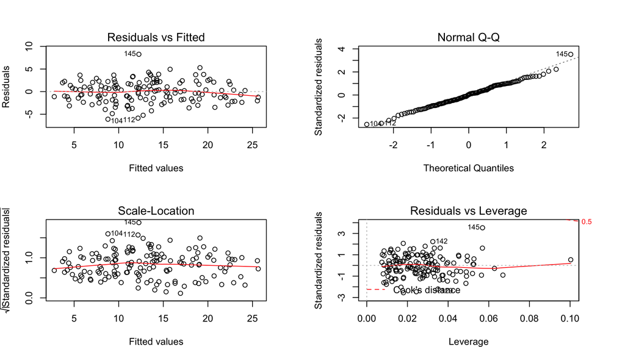

### Conclusion

An initial look at the scatter plots of the data indicated that the measures Sun and Days have a clear correlation with the percentage of sugar. DBH also appear to have come correlation, but it wasn’t that clear.

The first model fitted as a multiple linear regression with all predictive variables and no transformation resulted in a good fit, but, after evaluating the assumptions of the model, it was decided to try some transformations. The best transformation found for this problem was the power transformation of the response as Sugar$^2$. It resulted in larger $R^2$ value and fitted the model’s assumptions better than the first model.

Using exhaustive search, a best model was chosen according to BIC. The sugar level can be estimated by the model as:
$$\hat{\text{Sugar}} = \sqrt{\hat{\beta_0}+\hat{\beta_{Days}}\text{Days}+\hat{\beta_{DBH}}\text{DBH}+\hat{\beta_{Sun}}\text{Sun}}$$

Sun is a harder predictor variable to measure. But, as seen above, it is the most important predictor variable of all models tested. As it can be seen in the model selection section, the best model that doesn’t use it is much worse than the other models. Its $R^2$ value is almost half of the best model found. Therefore, it is essential for the prediction of Sugar that the variable Sun is available.

To maximize syrup production, based on the model chosen, it is important to notice that $\hat{\beta_{Days}}<0$, $\hat{\beta_{DBH}}>0$ and $\hat{\beta_{Sun}}>0$. That is, the model indicates that to maximize Sugar:

- the number of days that elapsed from the first tapping of the tree should be lower;
- the diameter at breast height of the tree should bigger;
- the sun exposure index should be higher.

So, sap should be collected from trees with bigger DBH and more sun exposure as close to the first tapping of the tree as possible.